# Predicción de la malignidad/benignidad de un cáncer de mama usando Redes Neuronales Artificiales (ANN)

Juan Manuel Vega Arias

30 de November, 2018

# Redes Neuronales Artificiales (ANN)

En la **estructura jerarquizada** que compone el cuerpo de la **Inteligencia Artificial**, tenemos varias subdivisiones entre las cuales está el **Aprendizaje Automático**. Este a su vez se divide en **Aprendizaje Supervisado, No Supervisado y Aprendizaje Reforzado**. El Aprendizaje Supervisado se subdivide en varias categorías, una de estas categorías es **Aprendizaje Profundo (Deep Learning) y Aprendizaje Superficial (Shallow Learning)** es otra. El Aprendizaje Profundo a la vez se subdivide en otras categorías, una de estas categorías son las **Redes Neuronales Artificiales (Artificial Neural Networks)**.

Estas fueron diseñadas como modelos computacionales de neuronas humanas por el neurofisiólogo **Warren McCulloch** y el neurocientífico computacinal **Walter Pitts**, y al igual que el cerebro se compone de las neuronas, las redes neuronales se componen de unos nodos, que funcionan conectados unos a otros formando una red, esta red de nodos trabaja conjuntamente para estimar un resultado que se ajuste a un modelo no lineal con el mínimo error posible.

## Arquitectura de las ANN Superficiales

Las redes neuronales se estructuran por capas en forma de una columna de nodos. La primera capa es la **Capa de Input**, las **Capas Intermedias**, a partir de la segunda capa, son las llamadas **Capas Ocultas** (Hidden Layers) y la última, es la **Capa de Output**. Aunque siempre tendremos una Capa de Input y una Capa de Output, puede haber más de una Capa Oculta, pero en la versión más descafeinada de redes neuronales sólo tenemos una, este modelo es llamado **Perceptrón Multicapa o Multilayer Perceptron (MLP)**.

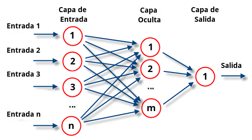

Multilayer Perceptron

Cada uno de los nodos de la capa de input representa una de las características que tendremos en cuenta para hacer la predicción. Cada uno de estos nodos está conectado a todos y cada uno de los nodos de la capa siguiente.

Dependiendo del peso asignado a cada uno de los nodos de la capa de input, las neuronas de una capa envían señales de valores diferentes, a las neuronas de la capa siguiente, estas señales se computan en el soma de la neurona receptora y según el resultado de este cálculo, la neurona enviará una señal a la siguiente neurona y así pasando por las diferentes capas hasta llegar al output.

### Backpropagation

Al comparar el output con el set de entrenamiento, los errores cometidos en los pesos asignados a las diferentes características son ajustados en cada nodo para reducir el error al mínimo. Gracias a esto las redes neuronales pueden ajustar sus predicciones a patrones no lineales que son a la vez más complejos y más parecidos a los que se dan en condiciones naturales. Dicha capacidad para extraer patrones complejos está directamente relacionada con el número de capas que formen el modelo.

| Fortalezas | Debilidades |
| --- | --- |
| Adaptabilidad a problemas de clasificación o predicción numérica | Lento de entrenar |
| Capacidad de modelar patrones complejos | Propenso a sobreajustar los datos de entrenamiento |
| Localiza relaciones subyacentes | Difícil de interpretar |

# Caso Estudio

Predicción de la malignidad/benignidad de un cáncer de mama usando Redes Neuronales Artificiales

## Paso 1 - Recolección de datos

Objetivo: Se quiere predecir el tipo de cáncer de mama (benigno/maligno) en función de las variables biológicas del cáncer de mama.

## Paso 2 - Exploración y preparación de datos

```r
breCan <- read.csv("BreastCancer2.csv")
str(breCan)
```

```
## 'data.frame':    683 obs. of  10 variables:
##  $ Cl.thickness   : int  5 5 3 6 4 8 1 2 2 4 ...
##  $ Cell.size      : int  1 4 1 8 1 10 1 1 1 2 ...
##  $ Cell.shape     : int  1 4 1 8 1 10 1 2 1 1 ...
##  $ Marg.adhesion  : int  1 5 1 1 3 8 1 1 1 1 ...
##  $ Epith.c.size   : int  2 7 2 3 2 7 2 2 2 2 ...
##  $ Bare.nuclei    : int  1 10 2 4 1 10 10 1 1 1 ...
##  $ Bl.cromatin    : int  3 3 3 3 3 9 3 3 1 2 ...
##  $ Normal.nucleoli: int  1 2 1 7 1 7 1 1 1 1 ...
##  $ Mitoses        : int  1 1 1 1 1 1 1 1 5 1 ...
##  $ Class          : Factor w/ 2 levels "benign","malignant": 1 1 1 1 1 2 1 1 1 1 ...
```

Ordenamos los datos al azar para no tener que hacerlo aguas abajo

```r
set.seed(12345)
shuffle <- sample(nrow(breCan),nrow(breCan))
breCan <- breCan[shuffle,]
```

Aunque todos los valores están entre el 1 y el 10, resultaría más conveniente que estuviesen entre 0 y 1 así que procedemos a la normalización de los datos. Para ello construimos la función `normalizar` de la siguente forma.

```r
normalizar <- function(x) {
    return((x - min(x)) / (max(x) - min(x)))
}
```

la función neuralnet no admite variables factor o categóricas. Por tanto, hay que transforma la variable “tipo de cáncer” a binaria. Para este cometido, se debe crear dos variables que sustituyen a la variable original. Una será la variable cáncer benigno (B) que tiene valores (TRUE o 1) en los casos “benignos” y (FALSE o 0) en los casos malignos. De manera semejante, pero contraria se crea la variable cáncer maligno (M).

```r
# Nos deshacemos del factor para transformarlo
BCan <- breCan[,-10]
# Cambiamos al factor por dos valores B y M cada uno con los valores posibles 0 y 1
mm <- model.matrix(~Class-1, breCan)
head(mm)
```

```
##     Classbenign Classmalignant
## 493           1              0
## 598           0              1
## 519           1              0
## 603           1              0
## 310           0              1
## 113           1              0
```

```r
colnames(mm) <- c("B","M")

# Normalizamos los datos con la función `lapply()`
BCan_norm <- as.data.frame(lapply(BCan, normalizar))
# Unimos los resultados de ambas transformaciones en una nueva matriz
breCan_norm <- cbind(BCan_norm,mm)
# Comprobamos que todas las variables están dentro de los rangos deseados
str(breCan_norm)
```

```
## 'data.frame':    683 obs. of  11 variables:
##  $ Cl.thickness   : num  0 0.778 0.222 0.333 0.444 ...
##  $ Cell.size      : num  0 1 0 0 0.333 ...
##  $ Cell.shape     : num  0 1 0 0 0.556 ...
##  $ Marg.adhesion  : num  0 1 0 0 1 ...
##  $ Epith.c.size   : num  0.111 0.556 0.111 0.111 0.111 ...
##  $ Bare.nuclei    : num  0.333 1 0 0 1 ...
##  $ Bl.cromatin    : num  0 1 0.111 0.111 0.333 ...
##  $ Normal.nucleoli: num  0 1 0 0 0 ...
##  $ Mitoses        : num  0 1 0 0 0 ...
##  $ B              : num  1 0 1 1 0 1 0 0 0 1 ...
##  $ M              : num  0 1 0 0 1 0 1 1 1 0 ...
```

Pasamos a crear los sets de entrenamiento y prueba de forma desordenada

```r
brca_entreno <- breCan_norm[1:455,]
brca_prueba <- breCan_norm[456:683,]
head(brca_entreno)
```

```
##     Cl.thickness Cell.size Cell.shape Marg.adhesion Epith.c.size
## 493    0.0000000 0.0000000  0.0000000             0    0.1111111
## 598    0.7777778 1.0000000  1.0000000             1    0.5555556
## 519    0.2222222 0.0000000  0.0000000             0    0.1111111
## 603    0.3333333 0.0000000  0.0000000             0    0.1111111
## 310    0.4444444 0.3333333  0.5555556             1    0.1111111
## 113    0.2222222 0.2222222  0.1111111             0    0.1111111
##     Bare.nuclei Bl.cromatin Normal.nucleoli Mitoses B M
## 493   0.3333333   0.0000000               0       0 1 0
## 598   1.0000000   1.0000000               1       1 0 1
## 519   0.0000000   0.1111111               0       0 1 0
## 603   0.0000000   0.1111111               0       0 1 0
## 310   1.0000000   0.3333333               0       0 0 1
## 113   0.2222222   0.2222222               0       0 1 0
```

## Paso 3 - Entrenamiento del modelo sobre los datos

Preparamos la ANN. Empezaremos entrenando una simple MLP feedforward. Antes de utilizar la función `neuralnet()` utilizamos como semilla generadora de los pesos iniciales el valor de set.seed(123).

```r
set.seed(123)
BC_model <- neuralnet( M + B ~ Cl.thickness + Cell.size + Cell.shape + Marg.adhesion + Epith.c.size + Bare.nuclei + Bl.cromatin + Normal.nucleoli + Mitoses, data = brca_entreno, hidden = 1)
plot(BC_model)
```

[output not shown]

## Paso 4 - Evaluación del rendimiento del modelo

Para ver como actúa el modelo sobre el data set de prueba utilizaremos la función `compute()` de la siguiente forma:

```r
resultado_modelo <- compute(BC_model, brca_prueba[1:9])
# De los dos componentes que retorna la función compute() utilizamos $net.result que almacena los valores previstos
breastcancer_prevision <- resultado_modelo$net.result

# Con la funcion cor() vemos la correlación entre dos vectores numéricos.
cor(breastcancer_prevision,brca_prueba$M )
```

```
##               [,1]
## [1,]  0.8910849397
## [2,] -0.8910849397
```

```r
cor(breastcancer_prevision,brca_prueba$B )
```

```
##               [,1]
## [1,] -0.8910849397
## [2,]  0.8910849397
```

## Paso 5 - Mejora de los resultados del modelo

```r
set.seed(123)
BC_model2 <- neuralnet( M + B ~ Cl.thickness + Cell.size + Cell.shape + Marg.adhesion + Epith.c.size + Bare.nuclei + Bl.cromatin + Normal.nucleoli + Mitoses, data = brca_entreno, hidden = 3)
plot(BC_model2)
```

[output not shown]

Vamos a comparar correlación como hicimos antes

```r
resultado_modelo2 <- compute(BC_model2, brca_prueba[1:9])
# De los dos componentes que retorna la función compute() utilizamos $net.result que almacena los valores previstos
breastcancer_prevision2 <- resultado_modelo2$net.result

# Con la funcion cor() vemos la correlación entre dos vectores numéricos.
cor(breastcancer_prevision2,brca_prueba$M )
```

```
##               [,1]
## [1,]  0.9141359332
## [2,] -0.9141107552
```

```r
cor(breastcancer_prevision2,brca_prueba$B )
```

```
##               [,1]
## [1,] -0.9141359332
## [2,]  0.9141107552
```